# rstudio::conf(2022L)

Exploratory Spatial Data Analysis in the tidyverse

- Hello it me
- I studied Geographic Information Systems in college where I was taught how to open menus and click button in ESRI’s toolsuite. Discovered R and thus other open-source tools like QGIS and python. Became an OSS convert.
- During college, I taught myselfg enough to be dangerous with the tidyverse.
  - I wanted to do my spatial analysis work in R. I couldn’t get my head around sp and s4 classes. I gave up and continued to work in QGIS
- 2018 rolls around and two things happen: I went to graduate school and the previously naiscent R package {sf} had reached full maturity with stable support and integration with dplyr and ggplot2
- Impact of {sf}:
  - {sf} is probably the most revolutionary spatial R package for programmers of my generation
  - the ability to couple familiar workflows using dplyr and ggplot2 cannot be understated.
  - seamlessly go from analysis, to visualization, and basic geospatial operations
- 2019 took Advanced Spatial Analysis where I was taught pysal, shapely, and geopandas
  - its not R.
  - R needs a spatial analysis library to compete
- discovered {spdep}, a great library, but again, idiosyncratic, and most importantly to me, not compatible with the tidyverse meaning it cannot be so easily adopted
- spdep is a package for spatial weights and statistics
  - it is somewhat of a legacy package,
    - it’s first release was in 2002 (for context I was in the 1st grade)
- inspired {sfdep} - is a tidy interface to spdep and extends it by providing additional statistics and operations
- sfdep design principles
- comparison of syntax

```r
library(spdep)
library(sfdep)
library(dplyr)
library(ggplot2)


# Using spdep
nb <- poly2nb(guerry)
listw <- nb2listw(nb)
lm_sp <- localmoran_perm(guerry$crime_pers, listw, nsim = 199)

head(lm_sp)

# note the attributes store the quadrant  which we want for visualization
quads <- attr(lm_sp, "quadr")

cbind(guerry, lm_sp, quads) |>
  ggplot(aes(fill = Ii)) +
  geom_sf(lwd = NA) +
  scale_fill_viridis_c(option = "A") +
  theme_void()


# Using sfdep
# can all be done in one pipe
guerry |>
  mutate(nb = st_contiguity(geometry),
         wt = st_weights(nb),
         lm = local_moran(crime_pers, nb, wt)) |>
  tidyr::unnest(lm) |>
  ggplot(aes(fill = ii)) +
  geom_sf(lwd = NA) +
  scale_fill_viridis_c(option = "A") +
  theme_void()
```

[output not shown]

- generating neighbors:
  - contiguity
  - knn
  - distance

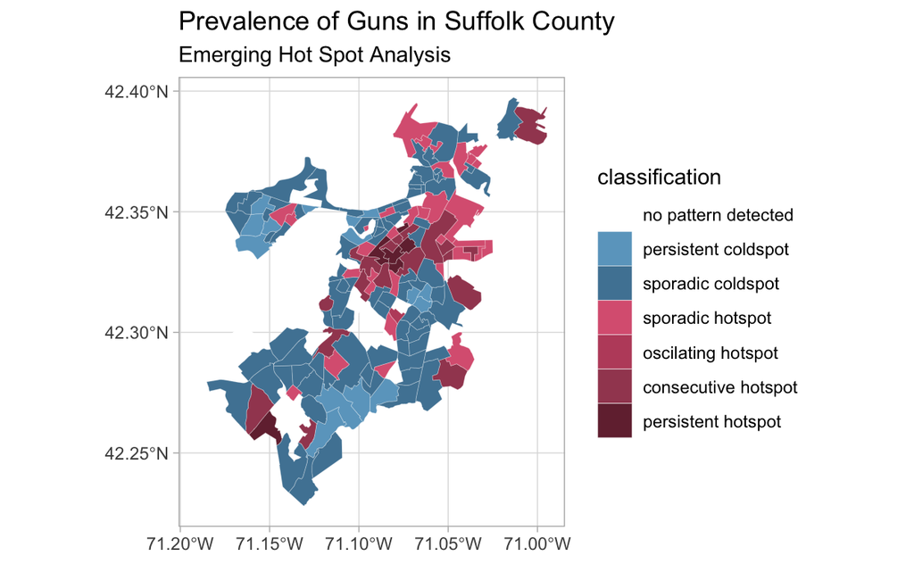

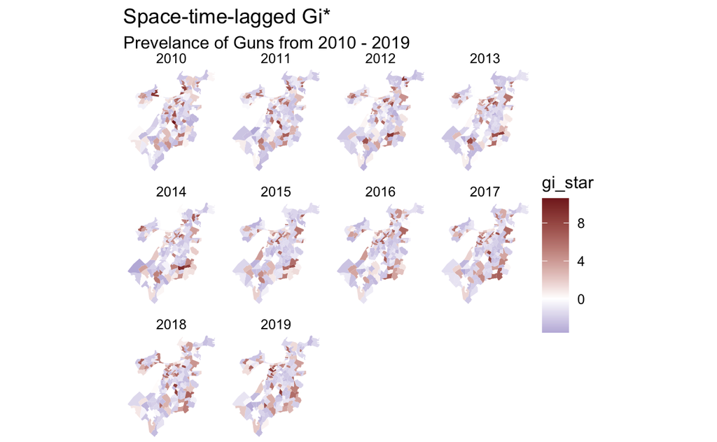

- What is Exploratory Data Analysis?
- Extending EDA to spatial data is ESDA
- Spatial data: point, lines, polygons, and pictures
  - Show points (Crime locations)
  - lines (road networks)
  - polygons (census regions)
- Tobler’s First Law
- Questions that ESDA can help answer:
  - Are things randomly distributed?
  - Are there spatial outliers?
- ESDA compares values to neighbors as opposed to the whole